# MCMC scheme for posterior inference of Gaussian DAG models: the learn_DAG() function

R package: BCDAG vignettes vol.2

2022-05-20

Abstract

This is the second of a series of three vignettes for the R package BCDAG. In this vignette we focus on function `learn_DAG()`, which implements a Markov Chain Monte Carlo (MCMC) algorithm to sample from the joint posterior of DAG structures and DAG-parameters under the Gaussian assumption.

**MCMC scheme for posterior inference of Gaussian DAG models: the learn_DAG() function**  
https://cran.r-project.org/web/packages/BCDAG/vignettes/bcdag_learnDAG.html

# 1 Preparations

## 1.1 Packages

## 1.2 Environment

```r
# rgb(73, 81, 112, maxColorValue = 255)
col.tw <- "#dbd7d2"  # Timberwolf
col.os <- "#414a4c"  # Outer Space
col.rp <- "#7851a9"  # Royal Purple
col.mb <- "#1a4876"  # Midnight Blue
col.pb <- "#1ca9c9"  # Pacific Blue
col.cb <- "#b0b7c6"  # Cadet Blue
col.el <- "#ceff1d"  # Electric Lime
col.cg <- "#00cc99"  # Caribbean Green
col.mt <- "#ff8243"  # Mango Tango
col.rm <- "#e3256b"  # Razzmatazz
col.sl <- "#fc2847"  # Scarlet

col.bg <- "#524A4E"  # Background
col.edge <- "#FDEFF4"  # Pale Pink
col.node <- "#4ECCA3"  # Teal

col.plos.yellow <- "#D6E13D"  # PLOS ONE Yellow
col.plos.pink <- "#CF00A3"  # PLOS ONE Pink
col.bmc.gray <- "#FFFDF6"  # BMC Gray
col.bmc.purple <- "#BF12F8"  # BMC Purple
col.bmc.navy <- "#1A2E4F"  # BMC Navy Blue
col.bmc.blue <- "#014A81"  # BMC Blue
col.bmc.sky <- "#0F99BE"  # BMC Sky Blue
col.bmc.green <- "#004940"  # BMC Deep Green
col.bmc.pink <- "#EF255F"  # BMC Pink

font.base <- "Candara"
# font.base <- "Times New Roman"
theme_set(theme_minimal(base_family = font.base))
options(dplyr.summarise.inform = TRUE)
# Twitter Logo and Acc
# Usage: add a code line below
# annotation_custom(grob = icon.grob, xmin = 1, xmax = 1, ymin = 1, ymax = 1)
icon.arr <- png::readPNG("fig/twitter.png")
icon.grob <- grid::rasterGrob(icon.arr,
                              width = unit(1.20 * 3, "cm"),
                              height = unit(0.99 * 3, "cm"),
                              interpolate = FALSE)

set.seed(2022)
```

# 2 Generating Data

## 2.1 Generating a binary adjacency matrix w/ `rDAG` function

```r
q <- 20
w <- 0.5
DAG <- rDAG(q = q, w = w)
class(DAG)
```

```
## [1] "matrix" "array"
```

```r
DAG
```

```
##    1 2 3 4 5 6 7 8 9 10 11 12 13 14 15 16 17 18 19 20
## 1  0 0 0 0 0 0 0 0 0  0  0  0  0  0  0  0  0  0  0  0
## 2  1 0 0 0 0 0 0 0 0  0  0  0  0  0  0  0  0  0  0  0
## 3  1 1 0 0 0 0 0 0 0  0  0  0  0  0  0  0  0  0  0  0
## 4  0 1 1 0 0 0 0 0 0  0  0  0  0  0  0  0  0  0  0  0
## 5  1 1 1 1 0 0 0 0 0  0  0  0  0  0  0  0  0  0  0  0
## 6  0 0 1 1 1 0 0 0 0  0  0  0  0  0  0  0  0  0  0  0
## 7  1 0 1 0 1 0 0 0 0  0  0  0  0  0  0  0  0  0  0  0
## 8  0 0 0 0 1 0 1 0 0  0  0  0  0  0  0  0  0  0  0  0
## 9  0 1 1 0 1 0 1 1 0  0  0  0  0  0  0  0  0  0  0  0
## 10 0 1 1 0 1 1 0 0 0  0  0  0  0  0  0  0  0  0  0  0
## 11 1 1 1 1 0 1 1 1 1  0  0  0  0  0  0  0  0  0  0  0
## 12 0 0 0 1 1 0 1 1 1  1  1  0  0  0  0  0  0  0  0  0
## 13 0 1 1 1 1 0 1 0 0  1  1  1  0  0  0  0  0  0  0  0
## 14 0 0 1 1 0 1 0 1 0  1  1  1  1  0  0  0  0  0  0  0
## 15 1 1 0 0 0 0 1 1 1  1  1  1  0  0  0  0  0  0  0  0
## 16 1 0 1 1 0 0 0 1 0  0  0  0  1  1  0  0  0  0  0  0
## 17 0 0 0 0 0 0 1 0 1  1  0  1  1  0  1  1  0  0  0  0
## 18 1 0 0 0 1 0 1 0 0  1  1  1  0  1  0  0  1  0  0  0
## 19 1 0 1 0 1 1 1 0 1  0  1  0  1  0  0  1  1  1  0  0
## 20 1 1 0 1 0 1 0 0 1  1  1  1  0  1  0  0  0  1  1  0
```

## 2.2 Generating Gaussian DAG parameters w/ `rDAGWishart` function

```r
a <- q
U <- diag(1, q)
outDL <- rDAGWishart(n = 2, DAG, a, U)
class(outDL)
```

```
## [1] "list"
```

```r
L <- outDL$L
class(L)
```

```
## [1] "array"
```

```r
dim(L)
```

```
## [1] 20 20  2
```

```r
class(L[, , 1])
```

```
## [1] "matrix" "array"
```

```r
diag(L[, , 1])
```

```
##  [1] 1 1 1 1 1 1 1 1 1 1 1 1 1 1 1 1 1 1 1 1
```

```r
D <- outDL$D
class(D)
```

```
## [1] "array"
```

```r
dim(D)
```

```
## [1] 20 20  2
```

```r
class(D[, , 1])
```

```
## [1] "matrix" "array"
```

```r
sum(D[, , 1] > 0)
```

```
## [1] 20
```

# 3 Generating Data from a Gaussian DAG

$p(X_1, ..., X_q, L, D, \mathfrak{D}) = p(X_1, ..., X_q | L, D, \mathfrak{D}) \cdot p(L, D | \mathfrak{D}) \cdot p(\mathfrak{D})$

$p(X_1, ..., X_q | L, D, \mathfrak{D}) = N_{q} (0, \; (L D^{-1} L^T)^{-1})$

$p(L, D | \mathfrak{D}) = \mathrm{DAG \text{-} Wishart} (a^{\mathfrak{D}}_c, U)$

$p(\mathfrak{D}) = \omega^{|S_{\mathfrak{D}}|} \; (1 - \omega)^{\frac{q(q-1)}{2} - |S_{\mathfrak{D}}|}$

$L$ and $D$: model parameters providing the decomposition of the precision matrix  
$U$ and $a^{\mathfrak{D}}_c$: hyper-parameters of prior to $(L, D)$  
$\omega$ and $S_{\mathfrak{D}}$: hyper-parameters of prior to $\mathfrak{D}$; a Binomial distribution on the number of edges in the graph

```r
# Precision matrix: L D^-1 L^T
Omega <- L[, , 1] %*% solve(D[, , 1]) %*% t(L[, , 1])

# Covariance matrix
Sigma <- solve(Omega)

# MultiVariate Normal Distribution
x.mvn <- mvtnorm::rmvnorm(n = 10, sigma = Sigma)
dim(x.mvn)
```

```
## [1] 10 20
```

# 4 Visualization of generated DAG via `tidygraph` and `ggraph`

Reference: https://ggplot2-book.org/networks.html#networks

```r
dag.tg <- tidygraph::as_tbl_graph(DAG, directed = TRUE)
class(dag.tg)
```

```
## [1] "tbl_graph" "igraph"
```

```r
dag.tg
```

```
## # A tbl_graph: 20 nodes and 108 edges
## #
## # A directed acyclic simple graph with 1 component
## #
## # Node Data: 20 x 1 (active)
##   name
##   <chr>
## 1 1
## 2 2
## 3 3
## 4 4
## 5 5
## 6 6
## # ... with 14 more rows
## #
## # Edge Data: 108 x 3
##    from    to weight
##   <int> <int>  <dbl>
## 1     2     1      1
## 2     3     1      1
## 3     3     2      1
## # ... with 105 more rows
```

```r
set_graph_style(plot_margin = margin(1, 1, 1, 1))
class(ggraph(dag.tg))
```

```
## [1] "ggraph" "gg"     "ggplot"
```

[figure not shown]

```r
p1 <- ggraph(dag.tg, layout = "circlepack") +
    geom_edge_link(
        arrow = arrow(angle = 15, length = unit(3, "pt")),
        start_cap = circle(3, "pt"),
        end_cap = circle(3, "pt"),
        color = col.edge,
        edge_width = 0.25, edge_alpha = 0.75
    ) +
    geom_node_point(color = col.node, size = 2, alpha = 0.9) +
    theme_minimal(base_family = font.base) +
    labs(title = "Gaussian DAG Structure for Synthesis",
         subtitle = "Nodes = 20, Edge Inclusion Ratio = 0.5",
         x = NULL, y = NULL) +
    theme(
        title = element_text(color = col.tw, size = 15),
        axis.text = element_blank(),
        panel.grid.major = element_blank(),
        panel.grid.minor = element_blank(),
        plot.background = element_rect(fill = col.bg),
    )
plot(p1)
```

```r
ggsave("fig/BCDAG-02-1.png", dpi = 300, width = 5, height = 5)
```

# 5 MCMC Sampler for DAG Parameters

## 5.1 learn_DAG

NOTE:  
`> there is no package called graph`  
See below solution,  
https://stackoverflow.com/questions/31252102/bayesian-network-with-r > install.packages(“BiocManager”) > BiocManager::install(c(“graph”, “Rgraphviz”))

```r
out <- learn_DAG(
    S = 5000,
    burn = 1000,
    data = x.mvn,
    # In this tutorial, these hyperparameter are known.
    a = a, U = U, w = w,
    fast = FALSE, save.memory = FALSE, collapse = FALSE, verbose = TRUE)
```

```
## Sampling DAGs...
##
## Sampling parameters...
##
```

## 5.2 Outputs

```r
class(out)
```

```
## [1] "bcdag"
```

```r
names(out)
```

```
## [1] "Graphs" "L"      "D"
```

```r
glimpse(out)
```

```
## List of 3
##  $ Graphs: num [1:20, 1:20, 1:5000] 0 0 1 0 0 0 0 1 0 0 ...
##  $ L     : num [1:20, 1:20, 1:5000] 1 0 0.0293 0 0 ...
##  $ D     : num [1:20, 1:20, 1:5000] 0.082 0 0 0 0 ...
##  - attr(*, "class")= chr "bcdag"
##  - attr(*, "type")= chr "complete"
##  - attr(*, "input")=List of 10
##   ..$ S          : num 5000
##   ..$ burn       : num 1000
##   ..$ data       : num [1:10, 1:20] 3.422 1.378 0.723 1.344 -1.366 ...
##   ..$ a          : num 20
##   ..$ U          : num [1:20, 1:20] 1 0 0 0 0 0 0 0 0 0 ...
##   ..$ w          : num 0.5
##   ..$ fast       : logi FALSE
##   ..$ save.memory: logi FALSE
##   ..$ collapse   : logi FALSE
##   ..$ verbose    : logi TRUE
```

```r
dim(out$Graphs)
```

```
## [1]   20   20 5000
```

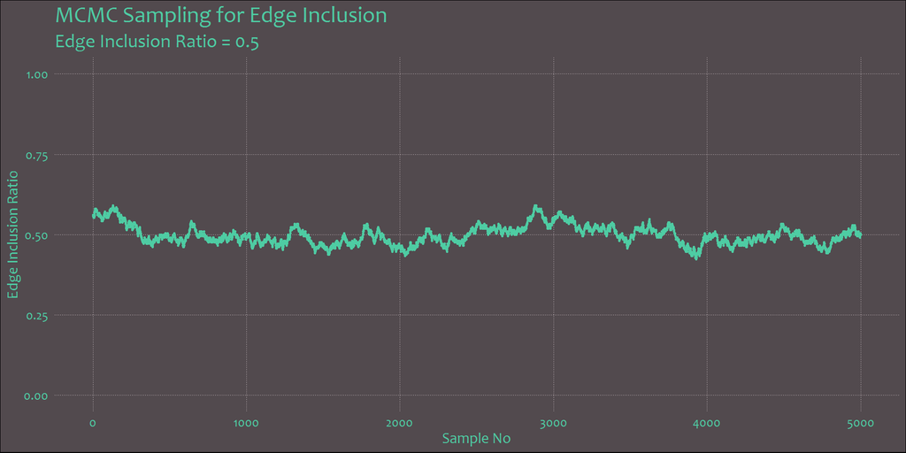

```r
data.frame(
    sample.no = 1:5000,
    inclusion.ratio = colSums(out$Graphs, dims = 2) / (q * (q - 1) / 2 + q)
) %>% ggplot() +
    geom_point(aes(x = sample.no, y = inclusion.ratio),
               color = col.node, size = 0.5) +
    lims(y = c(0, 1)) +
    labs(title = "MCMC Sampling for Edge Inclusion",
         subtitle = "Edge Inclusion Ratio = 0.5",
         x = "Sample No", y = "Edge Inclusion Ratio") +
    theme_minimal(base_family = font.base) +
    theme(
        title = element_text(color = col.node, size = 15),
        axis.title = element_text(color = col.node, size = 12),
        axis.text = element_text(color = col.node, size = 10),
        panel.grid.minor = element_blank(),
        panel.grid.major = element_line(color = col.edge, linetype = 3,
                                        size = 0.1),
        plot.background = element_rect(fill = col.bg)
    )
```

```r
ggsave("fig/BCDAG-02-2.png", dpi = 300, width = 8, height = 4)
```